Data Collection. o Collect the dataset or Create the dataset • Data Preprocessing. o Import the Libraries. o Importing the dataset. o Checking for Null Values. o Data Visualization. o Outlier Detection o Splitting Dependent and Independent variables o- Encoding o Feature Scaling. o Splitting Data into Train and Test. • Model Building o Import the model building Libraries o Initializing the model o Training and testing the model o Evaluation of Model o Save the Model • Application Building o Create an HTML file o Build a Python Code

# Data Preprocessing.

```python
Import the Libraries.
    o	Importing the dataset.
    o	Checking for Null Values.
    o	Data Visualization.
    o	Outlier Detection
    o	Splitting Dependent and Independent variables
    o-	Encoding
    o	Feature Scaling.
    o	Splitting Data into Train and Test.
```

```python
#Importing the libraries.
import numpy as np
import pandas as pd
import matplotlib.pyplot as plt
import seaborn as sns
```

```python
#Importing the dataset.
df=pd.read_csv("50_Startups.csv")
```

```python
df.head()
#displays the profit earned by a company based on the other independent values
```

|  | R&D Spend | Administration | Marketing Spend | State | Profit |
| --- | --- | --- | --- | --- | --- |
| 0 | 165349.20 | 136897.80 | 471784.10 | New York | 192261.83 |
| 1 | 162597.70 | 151377.59 | 443898.53 | California | 191792.06 |
| 2 | 153441.51 | 101145.55 | 407934.54 | Florida | 191050.39 |
| 3 | 144372.41 | 118671.85 | 383199.62 | New York | 182901.99 |
| 4 | 142107.34 | 91391.77 | 366168.42 | Florida | 166187.94 |

```python
#to check the descriptive statistics of the data
df.describe()
```

|  | R&D Spend | Administration | Marketing Spend | Profit |
| --- | --- | --- | --- | --- |
| count | 108.000000 | 108.000000 | 108.000000 | 108.000000 |
| mean | 74959.338704 | 121750.788889 | 214952.664722 | 113523.760000 |
| std | 44996.368152 | 27322.385654 | 117937.942120 | 38991.013654 |
| min | 0.000000 | 51283.140000 | 0.000000 | 14681.400000 |
| 25% | 38558.510000 | 105077.645000 | 134050.070000 | 90708.190000 |
| 50% | 75791.365000 | 122699.795000 | 239452.750000 | 109543.120000 |
| 75% | 101913.080000 | 145077.580000 | 298664.470000 | 141585.520000 |
| max | 165349.200000 | 182645.560000 | 471784.100000 | 192261.830000 |

```python
#gves the data size of each and every column
df.info()
#state is object which means it is categorical
```

```
<class 'pandas.core.frame.DataFrame'>
RangeIndex: 108 entries, 0 to 107
Data columns (total 5 columns):
 #   Column           Non-Null Count  Dtype
---  ------           --------------  -----
 0   R&D Spend        108 non-null    float64
 1   Administration   108 non-null    float64
 2   Marketing Spend  108 non-null    float64
 3   State            108 non-null    object
 4   Profit           108 non-null    float64
dtypes: float64(4), object(1)
memory usage: 4.3+ KB
```

```python
#check the correlation
df.corr()
#gves a correlation between all the columns in m data set
```

```
C:\Users\CHARUTHA MURARI S\AppData\Local\Temp\ipykernel_5352\3541237067.py:2: FutureWarning: The default value of numeric_only in DataFrame.corr is deprecated. In a future version, it will default to False. Select only valid columns or specify the value of numeric_only to silence this warning.
  df.corr()
```

|  | R&D Spend | Administration | Marketing Spend | Profit |
| --- | --- | --- | --- | --- |
| R&D Spend | 1.000000 | 0.241379 | 0.725978 | 0.964770 |
| Administration | 0.241379 | 1.000000 | -0.024699 | 0.198849 |
| Marketing Spend | 0.725978 | -0.024699 | 1.000000 | 0.748957 |
| Profit | 0.964770 | 0.198849 | 0.748957 | 1.000000 |

# there should be less correlation btw th eindependent coulmns

# if two independent features have high correlation, both basically gives the same informaton

# MULTI COLLINEARITY - IT EXISTS WHEN BOTH THE INDEPENDENT FACTORS ARE HIGHLY INTERNALLY CORRECLATED IN A REGRESSION MODEL WHICH MAKES IT DIFFICULAT TO DETERMINE THE EFFECT OF EACH AND EVERY INDEPENDENT VARIABLES ON THE DEPENDENT VARIABLE. IT CAN BE DROPPED.

```python
df.corr().Profit.sort_values(ascending=False)
#gives the correlation of all the independent values in descending order
```

```
C:\Users\CHARUTHA MURARI S\AppData\Local\Temp\ipykernel_5352\2059948296.py:1: FutureWarning: The default value of numeric_only in DataFrame.corr is deprecated. In a future version, it will default to False. Select only valid columns or specify the value of numeric_only to silence this warning.
  df.corr().Profit.sort_values(ascending=False)
```

```
Profit             1.000000
R&D Spend          0.964770
Marketing Spend    0.748957
Administration     0.198849
Name: Profit, dtype: float64
```

```python
#handle the null values
df.isnull().any()
#there is no null values in the dataset
```

```
R&D Spend          False
Administration     False
Marketing Spend    False
State              False
Profit             False
dtype: bool
```

```python
df.isnull().sum()
```

```
R&D Spend          0
Administration     0
Marketing Spend    0
State              0
Profit             0
dtype: int64
```

```python
#how many no.of.ubnique categories are present in the sate column
df.State.nunique()
```

```
3
```

```python
# to display those 3 categories
df.State.unique()
```

```
array(['New York', 'California', 'Florida'], dtype=object)
```

```python
#to display the count of each dataset
df.State.value_counts()
```

```
New York      39
California    36
Florida       33
Name: State, dtype: int64
```

```python
#Data Visualization
```

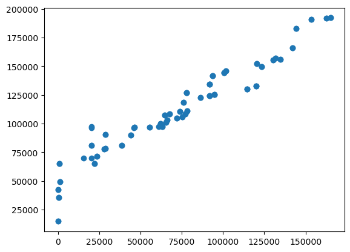

```python
#create a scatter plot. since the dependency of profit and R&D is very close, i has a linear correlation
plt.scatter(df["R&D Spend"],df["Profit"])
#they are directlt propotional to each other. that's why they are hihly correlated
```

```
C:\Users\CHARUTHA MURARI S\AppData\Local\Temp\ipykernel_5352\1555819897.py:2: FutureWarning: The default value of numeric_only in DataFrame.corr is deprecated. In a future version, it will default to False. Select only valid columns or specify the value of numeric_only to silence this warning.
  sns.heatmap(df.corr(),annot=True)
```

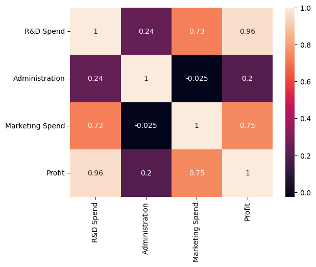

```python
#plot a heat map -> pictorial representation of the correlation matrix
sns.heatmap(df.corr(),annot=True)
#darker shade=> not correlated
#lighter shade=> highly correlated
```

```python
#taking only numeric coulmn
#sns.heatmap(df.corr(numeric_only=True),annot=True)
```

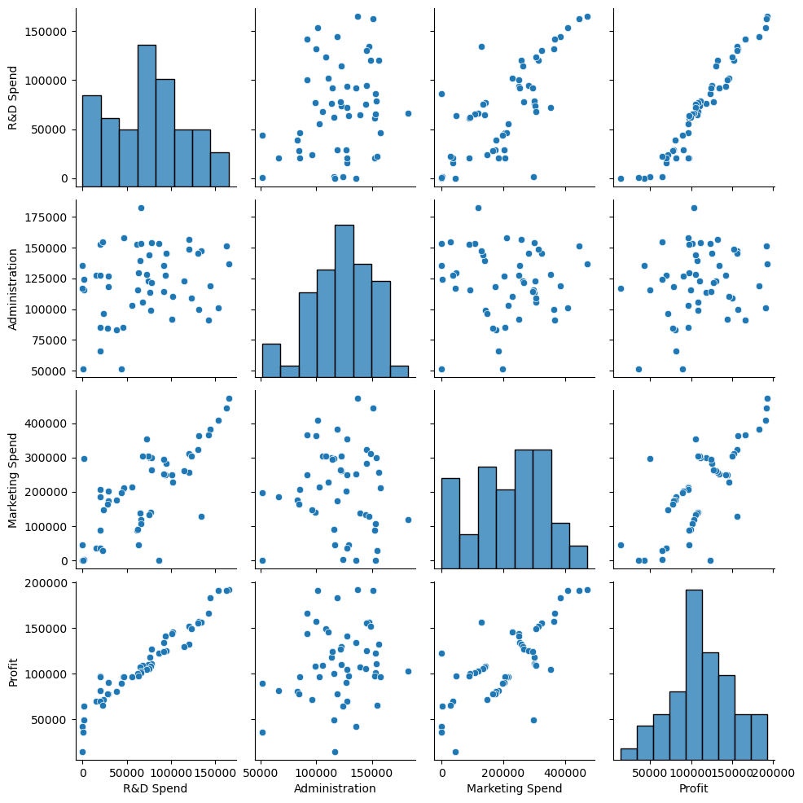

```python
#plot a pairplot and check all the dependencie sof the column
sns.pairplot(df)
#we get histograms and scatter plot
#it can be observed that R&D and Profit is linearly correlated
#R&D and Administration is less correlated
#R&D and marketing are little linearly correlated
```

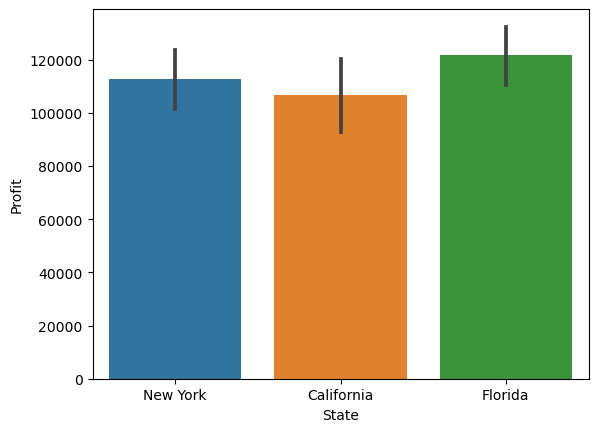

```python
#use a bar plot to check which states have the highest profit
sns.barplot(x=df["State"],y=df["Profit"])
```

```
C:\Users\CHARUTHA MURARI S\AppData\Local\Temp\ipykernel_5352\2753062866.py:1: FutureWarning:

The `ci` parameter is deprecated. Use `errorbar=('ci', 0)` for the same effect.

  sns.barplot(x=df["State"],y=df["Profit"], ci=0)
```

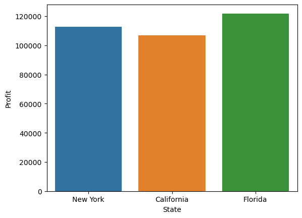

```python
sns.barplot(x=df["State"],y=df["Profit"], ci=0)
#Florida has hight profit
```

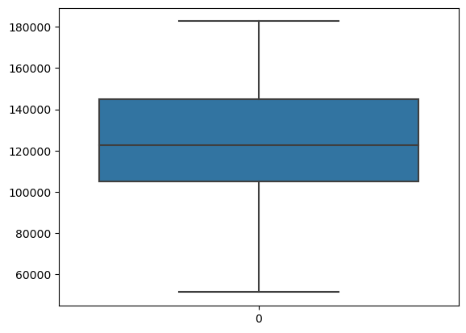

```python
#5.Data outlier detection
sns.boxplot(df["Administration"])
#no outlier
```

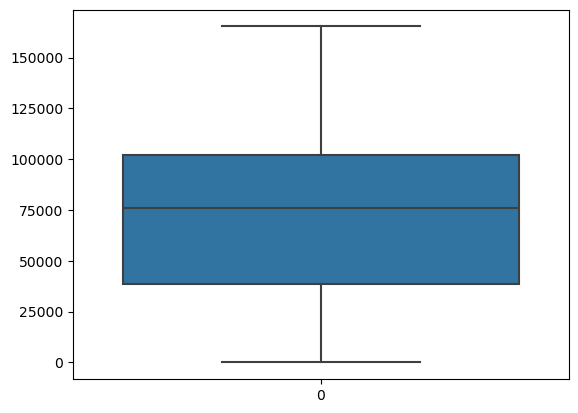

```python
sns.boxplot(df["R&D Spend"])
```

```python
#6.Split the dependent and ndependent variables
```

```python
df.head()
```

|  | R&D Spend | Administration | Marketing Spend | State | Profit |
| --- | --- | --- | --- | --- | --- |
| 0 | 165349.20 | 136897.80 | 471784.10 | New York | 192261.83 |
| 1 | 162597.70 | 151377.59 | 443898.53 | California | 191792.06 |
| 2 | 153441.51 | 101145.55 | 407934.54 | Florida | 191050.39 |
| 3 | 144372.41 | 118671.85 | 383199.62 | New York | 182901.99 |
| 4 | 142107.34 | 91391.77 | 366168.42 | Florida | 166187.94 |

```python
#drop profit so as to grab all the other independent variables
#independent variables should be a 2D array or a daaframe
x=df.drop(columns=["Profit"],axis=1)
x.head()
```

|  | R&D Spend | Administration | Marketing Spend | State |
| --- | --- | --- | --- | --- |
| 0 | 165349.20 | 136897.80 | 471784.10 | New York |
| 1 | 162597.70 | 151377.59 | 443898.53 | California |
| 2 | 153441.51 | 101145.55 | 407934.54 | Florida |
| 3 | 144372.41 | 118671.85 | 383199.62 | New York |
| 4 | 142107.34 | 91391.77 | 366168.42 | Florida |

```python
x.shape
```

```
(108, 4)
```

```python
type(x)
```

```
pandas.core.frame.DataFrame
```

```python
#dependent variable should be 1D or a Series
y=df["Profit"]
y.head()
```

```
0    192261.83
1    191792.06
2    191050.39
3    182901.99
4    166187.94
Name: Profit, dtype: float64
```

```python
#7. Encoding
```

```python
x.head()
```

|  | R&D Spend | Administration | Marketing Spend | State |
| --- | --- | --- | --- | --- |
| 0 | 165349.20 | 136897.80 | 471784.10 | New York |
| 1 | 162597.70 | 151377.59 | 443898.53 | California |
| 2 | 153441.51 | 101145.55 | 407934.54 | Florida |
| 3 | 144372.41 | 118671.85 | 383199.62 | New York |
| 4 | 142107.34 | 91391.77 | 366168.42 | Florida |

```python
from sklearn.preprocessing import LabelEncoder
le=LabelEncoder()
```

```python
x["State"]=le.fit_transform(x["State"])
x.head()
```

|  | R&D Spend | Administration | Marketing Spend | State |
| --- | --- | --- | --- | --- |
| 0 | 165349.20 | 136897.80 | 471784.10 | 2 |
| 1 | 162597.70 | 151377.59 | 443898.53 | 0 |
| 2 | 153441.51 | 101145.55 | 407934.54 | 1 |
| 3 | 144372.41 | 118671.85 | 383199.62 | 2 |
| 4 | 142107.34 | 91391.77 | 366168.42 | 1 |

```python
print(le.classes_)
#to know which classes were encoded as what
```

[output not shown]

```python
#to know which value they have taken for encoding also
mapping = dict(zip(le.classes_,range(len(le.classes_))))
mapping
```

[output not shown]

# 8. Feature Scaling - to standardize out data

- standard scalar -> mean=0 and sd=1
- min max scalar - has a range of 0 to 1

```python
from sklearn.preprocessing import MinMaxScaler
ms=MinMaxScaler()
```

```python
x_scaled=ms.fit_transform(x)
```

```python
x_scaled= pd.DataFrame(ms.fit_transform(x),columns = x.columns)
x_scaled.head()
```

|  | R&D Spend | Administration | Marketing Spend | State |
| --- | --- | --- | --- | --- |
| 0 | 1.000000 | 0.651744 | 1.000000 | 1.0 |
| 1 | 0.983359 | 0.761972 | 0.940893 | 0.0 |
| 2 | 0.927985 | 0.379579 | 0.864664 | 0.5 |
| 3 | 0.873136 | 0.512998 | 0.812235 | 1.0 |
| 4 | 0.859438 | 0.305328 | 0.776136 | 0.5 |

```python
#split the data into training and testing part
```

```python
from sklearn.model_selection import train_test_split
x_train,x_test,y_train,y_test = train_test_split(x_scaled,y,test_size =0.2,random_state=0)
```

```python
print(x_train.shape,x_test.shape,y_train.shape,y_test.shape)
```

```
(86, 4) (22, 4) (86,) (22,)
```

# MODEL BUILDING

Import the model building Libraries o Initializing the model o Training and testing the model o Evaluation of Model o Save the Model

```python
#1.Import the model building Libraries
from sklearn.linear_model import LinearRegression
```

```python
#2 Initializing the model
lr=LinearRegression()
```

```python
#3.Train the model
lr.fit(x_train,y_train)
```

```
LinearRegression()
```

```python
#4.Test the model
y_pred=lr.predict(x_test)
y_pred
```

```
array([ 48379.24868386, 134848.9192467 ,  76483.10965225, 181561.78529188,
       112966.00035112, 134241.68257226, 129222.38731942, 160017.05919784,
       116752.96050775,  46260.9926407 , 102266.36060189, 115568.27177598,
        48379.24868386, 119114.16525526,  88602.22002789, 127101.40273623,
       127101.40273623,  90942.33421515,  58677.7334991 , 146304.26215166,
       149410.05441   , 152502.87810448])
```

```python
y_test
```

```
84      64926.08
10     146121.95
75      90708.19
2      191050.39
24     108552.04
100    144259.40
107    124266.90
7      155752.60
16     126992.93
86      42559.73
68     101004.64
22     110352.25
45      64926.08
60     111313.02
76      89949.14
52     134307.35
13     134307.35
73      96712.80
85      49490.75
54     129917.04
103    132602.65
8      152211.77
Name: Profit, dtype: float64
```

```python
#create a dataframe to analyse the actual and predicted profit
profit=pd.DataFrame({"Actual_profit":y_test,"Predicted _profit":y_pred})
profit
```

|  | Actual_profit | Predicted _profit |
| --- | --- | --- |
| 84 | 64926.08 | 48379.248684 |
| 10 | 146121.95 | 134848.919247 |
| 75 | 90708.19 | 76483.109652 |
| 2 | 191050.39 | 181561.785292 |
| 24 | 108552.04 | 112966.000351 |
| 100 | 144259.40 | 134241.682572 |
| 107 | 124266.90 | 129222.387319 |
| 7 | 155752.60 | 160017.059198 |
| 16 | 126992.93 | 116752.960508 |
| 86 | 42559.73 | 46260.992641 |
| 68 | 101004.64 | 102266.360602 |
| 22 | 110352.25 | 115568.271776 |
| 45 | 64926.08 | 48379.248684 |
| 60 | 111313.02 | 119114.165255 |
| 76 | 89949.14 | 88602.220028 |
| 52 | 134307.35 | 127101.402736 |
| 13 | 134307.35 | 127101.402736 |
| 73 | 96712.80 | 90942.334215 |
| 85 | 49490.75 | 58677.733499 |
| 54 | 129917.04 | 146304.262152 |
| 103 | 132602.65 | 149410.054410 |
| 8 | 152211.77 | 152502.878104 |

```python
#Random value prediction
df.head()
```

|  | R&D Spend | Administration | Marketing Spend | State | Profit |
| --- | --- | --- | --- | --- | --- |
| 0 | 165349.20 | 136897.80 | 471784.10 | New York | 192261.83 |
| 1 | 162597.70 | 151377.59 | 443898.53 | California | 191792.06 |
| 2 | 153441.51 | 101145.55 | 407934.54 | Florida | 191050.39 |
| 3 | 144372.41 | 118671.85 | 383199.62 | New York | 182901.99 |
| 4 | 142107.34 | 91391.77 | 366168.42 | Florida | 166187.94 |

```python
lr.predict([[165349.20,136897.80,471784.10,2]])
#give it in the form of a dataframe
```

```
C:\Users\CHARUTHA MURARI S\anaconda3\Lib\site-packages\sklearn\base.py:439: UserWarning: X does not have valid feature names, but LinearRegression was fitted with feature names
  warnings.warn(
```

```
array([2.90981647e+10])
```

```python
 lr.predict(ms.transform([[165349.20,136897.80,471784.10,2]]))
```

```
C:\Users\CHARUTHA MURARI S\anaconda3\Lib\site-packages\sklearn\base.py:439: UserWarning: X does not have valid feature names, but MinMaxScaler was fitted with feature names
  warnings.warn(
C:\Users\CHARUTHA MURARI S\anaconda3\Lib\site-packages\sklearn\base.py:439: UserWarning: X does not have valid feature names, but LinearRegression was fitted with feature names
  warnings.warn(
```

```
array([193329.17668167])
```

```python
#5.Evaluation of the model
```

```python
from sklearn import metrics
```

```python
# R- Square
# evaluating testing accuracy
#ACCURACY
print(metrics.r2_score(y_test,y_pred))
```

```
0.9258962347553819
```

```python
#mean squared error
print(metrics.mean_squared_error(y_test,y_pred))
```

```
96015241.547077
```

```python
# RMSE (Root Mean Square Error)
print(np.sqrt(metrics.mean_squared_error(y_test,y_pred)))
```

```
9798.736732205687
```

```python
#Linear regression with ols
```

```python
import statsmodels.api as sm
model=sm.OLS(y_train,x_train).fit()
prediction=model.predict(x_test)
prediction
```

```
84      40729.658668
10     125715.802262
75      78276.580387
2      178294.833362
24      99606.661881
100    114195.293178
107    127685.712251
7      169881.155797
16     111836.797748
86      32777.338895
68     108777.868047
22     119741.110576
45      40729.658668
60     140152.512072
76      53215.304174
52     125560.034171
13     125560.034171
73     109318.123196
85      66091.629765
54     148597.322205
103    159234.879137
8      168682.082094
dtype: float64
```

R&D Spend Administration Marketing Spend State  
m1 m2 m3 m4

y^=m1x1+m2x2+m3x3+m4x4

```python
model.summary()
```

OLS Regression Results

| Dep. Variable: | Profit | R-squared (uncentered): | 0.981 |
| --- | --- | --- | --- |
| Model: | OLS | Adj. R-squared (uncentered): | 0.980 |
| Method: | Least Squares | F-statistic: | 1048. |
| Date: | Thu, 21 Sep 2023 | Prob (F-statistic): | 1.65e-69 |
| Time: | 14:08:13 | Log-Likelihood: | -957.92 |
| No. Observations: | 86 | AIC: | 1924. |
| Df Residuals: | 82 | BIC: | 1934. |
| Df Model: | 4 |  |  |
| Covariance Type: | nonrobust |  |  |

|  | coef | std err | t | P>\|t\| | [0.025 | 0.975] |
| --- | --- | --- | --- | --- | --- | --- |
| R&D Spend | 1.143e+05 | 1.07e+04 | 10.659 | 0.000 | 9.29e+04 | 1.36e+05 |
| Administration | 5.117e+04 | 6464.156 | 7.916 | 0.000 | 3.83e+04 | 6.4e+04 |
| Marketing Spend | 5.451e+04 | 9934.576 | 5.487 | 0.000 | 3.47e+04 | 7.43e+04 |
| State | 1.143e+04 | 4160.872 | 2.748 | 0.007 | 3155.541 | 1.97e+04 |

| Omnibus: | 5.934 | Durbin-Watson: | 1.737 |
| --- | --- | --- | --- |
| Prob(Omnibus): | 0.051 | Jarque-Bera (JB): | 3.407 |
| Skew: | -0.283 | Prob(JB): | 0.182 |
| Kurtosis: | 2.206 | Cond. No. | 7.87 |

Notes:  
[1] R² is computed without centering (uncentered) since the model does not contain a constant.  
[2] Standard Errors assume that the covariance matrix of the errors is correctly specified.